# Intro to R and R- Spatial; insight on datacubes

Edzer Pebesma

2/16/2022

## What is R?

According to the [website](https://r-project.org), “R is a free software environment for statistical computing and graphics. It compiles and runs on a wide variety of UNIX platforms, Windows and MacOS.”

## What is Rstudio?

[Rstudio](https://rstudio.com/) is a company that develops and distributes a frontend, or IDE, for R that is free and open source, called Rstudio desktop. It also develops commercial derivatives, mostly targeted at businesses. These products use the same R (processor) as R.

Other front-ends include

- R command line
- teminal-based, e.g. vim with Nvim-R, or emacs with ESS
- a browser communicating with Rstudio server (also free)
- R in visual studio
- Jupyter or JupyterLab (Jupyter developed from IPython notebooks and once stood for “Julia, Python, R”, it now probably caters more languages)

## What is markdown, R-markdown?

Markdown is a leightweight markup language for formatted text (headers, lists, figures, equations).

[R-markdown](https://rmarkdown.rstudio.com/) extends markdown with sections containing R code, and allows for notebook functionality:

- running the code in the code sections, inserting output (text, figures) in the rendered document (html, pdf)
- interacting with the document in a notebook-style (run individual code sections, scrutinize output)

These slides are written in R-markdown, and can be found as files with extension `.Rmd` on this repository: https://github.com/edzer/winterschool ; the rendered html output files are linked in the README file in the repository.

## Why is R used?

- R is a language dedicated to data analysis, unlike general programming languages like C++ or Python. In R, you don’t have to load a package or module first before you can plot data, as in

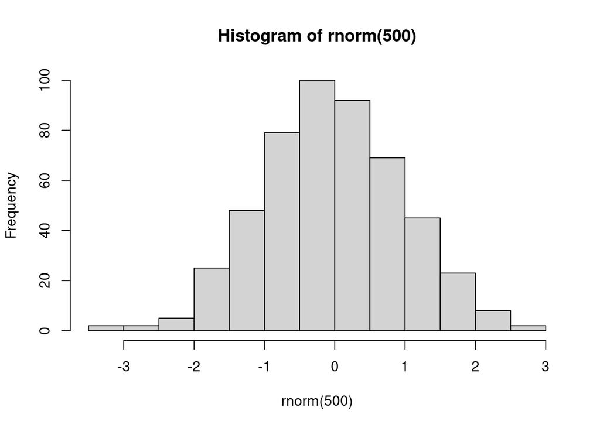

```r
hist(rnorm(500))
```

- Many people use R because many other people do:
  - to solve data analysis problems
  - to share data analysis problems (share data, share R script)
  - to wrap a new data analysis method in an R package, and distribute that, e.g. through [CRAN](https://cran.r-project.org/) and/or [github](https://github.com/r-spatial/stars)
- one aspect, often overlooked, in which R distinguishes itself from general purpose language such as Python, is the availability of a `NA` value for “not available”. This is distinct from the “not a number”, which is the result of an invalid computation:

```r
0/0 # NaN
```

```
## [1] NaN
```

```r
a <- c(1, NA, 3)
a + 2.5
```

```
## [1] 3.5  NA 5.5
```

```r
mean(a)
```

```
## [1] NA
```

```r
mean(a, na.rm = TRUE)
```

```
## [1] 2
```

```r
c("Alice", NA, "Charlie")
```

```
## [1] "Alice"   NA        "Charlie"
```

```r
b <- c(TRUE, FALSE, NA, TRUE)
!b
```

```
## [1] FALSE  TRUE    NA FALSE
```

## What is an R package?

An R package wraps

- R code
- possibly further code written in C, C++, Fortran, java, etc.
- documentation
- data sets
- examples, tutorials

in a structured way, so that others can easily install it, e.g. from CRAN by

```r
install.packages("stars")
```

or directly from github by

```r
library(remotes) # install.packages("remotes") if you don't have this
install_github("r-spatial/stars")
```

After that, a package can be loaded by

```r
library(stars)
```

after which its full functionality becomes available to the R user.

**R packages extend R with new, often dedicated or domain specific functionality.**

## R-Spatial

For a historical perspective, see the [youtube video](https://www.youtube.com/watch?v=mEAyQ8bv1zU) by Roger Bivand (Why R? 2020 Keynote: “Applied Spatial Data Analysis with R: retrospect and prospect”).

For a current perspective, see my [youtube video](https://www.youtube.com/watch?v=cK08bxUJn5A) (UseR! 2021 keynote, “R-Spatial”).

For a current book on Spatial Data Science, see [here](https://r-spatial.org/book). We will use this book in the current summer school. Please open chapter 1.

## Intro to R Spatial

Go to chapter 1 of the [Spatial Data Science book](https://r-spatial.org/book).

## An insight on datacubes

Go to the data cubes chapter of the [Spatial Data Science book](https://r-spatial.org/book).

## Preparation for Day 7

- make sure you have R and Rstudio running on your computer, and install a number of spatial packages like `sf`, `stars`, and `terra`
- read chapters 3 and 7 from the [Spatial Data Science book](https://r-spatial.org/book).

## Preparation for Day 8

- read chapters 5 and 6 from the [Spatial Data Science book](https://r-spatial.org/book).